# Quantitative Equity Research

Author

Brian Huang

# Introduction

A large literature documents firm characteristics that predict stock returns, but the growing number of proposed factors has raised concerns about data mining and robustness. Jensen, Kelly, and Pedersen (JKP) systematically evaluate these factors and find that many remain significant after risk adjustment and multiple-testing corrections.

This project develops an end-to-end quantitative equity research process based on JKP’s framework. It first evaluates 153 equity factors through replication and a more recent sample, then uses the validated characteristics to construct alpha signals. The rule-based Quality Minus Junk (QMJ) strategy serves as an interpretable benchmark, while Logistic Regression, Random Forest, and XGBoost examine whether nonlinear models improve return prediction.

Finally, the alpha forecasts are combined with a Bloomberg-inspired fundamental factor risk model to construct risk-aware portfolios. Out-of-sample performance is evaluated using cumulative return, annualized return, volatility, Sharpe ratio, and maximum drawdown. The project therefore connects factor validation, alpha modeling, risk estimation, and portfolio construction within one systematic investment process.

# Data

## Data Sources

The analysis begins with raw security-level data obtained from WRDS. Market information is primarily sourced from CRSP, while accounting fundamentals are obtained from Compustat. The CRSP/Compustat Merged (CCM) linking table is used to combine market and accounting information at the security level.

The 153 stock characteristics are derived variables rather than raw data inputs. They are constructed from CRSP and Compustat variables following the definitions and methodology of Jensen, Kelly, and Pedersen (JKP).

| Component | Data Source / Methodology | Purpose |
| --- | --- | --- |
| **Stock Returns and Prices** | CRSP | Monthly returns, prices, shares outstanding, exchange information, and security identifiers. |
| **Accounting Fundamentals** | Compustat Fundamentals Annual & Quarterly | Obtain balance sheet, income statement, and cash flow variables required to construct accounting-based characteristics. |
| **CRSP–Compustat Link** | CRSP/Compustat Merged Database (CCM) | Link CRSP securities (`PERMNO`) to Compustat firms (`GVKEY`). |
| **Market Excess Return** | U.S. market return and risk-free rate | Estimate CAPM betas and factor alphas for factor validation. |
| **Factor Definitions** | Jensen, Kelly, and Pedersen (JKP) | Definitions and construction methodology for the 153 stock characteristics. |

## Data Construction Pipeline

The complete data processing pipeline from WRDS raw data to factor validation results is summarized below.

CRSP market data and Compustat accounting fundamentals are first linked at the security level using the CCM linking table. The merged data are organized as a monthly security-level panel, where each observation represents one security in one month.

Stock characteristics are then constructed using the methodology of Jensen, Kelly, and Pedersen. Each month, securities are sorted cross sectionally according to each characteristic. These rankings are used to form characteristic portfolios, from which long-short factor returns are calculated. Repeating this procedure across the full set of characteristics produces 153 monthly factor-return series that are subsequently used in the factor validation analysis.

```
flowchart TD

    A["CRSP Market Data"] --> D["Security Month Panel"]
    B["Compustat Fundamentals"] --> D
    C["CCM Link Table"] --> D

    D --> E["153 Stock Characteristics"]

    E --> F["Cross-Sectional Sorting"]

    F --> G["Factor Portfolios"]

    G --> H["153 Factor Returns"]

    H --> I["CAPM Alpha Tests"]

    J["Market Excess Return"] --> I

    I --> K["Multiple Testing"]

    K --> L["Factor Replication Results"]
```

## Sample Design and Timing

| Analysis | Sample Period | Frequency | Purpose |
| --- | --- | --- | --- |
| JKP Replication | Full historical sample | Monthly | Reproduce the main factor-validation results reported in JKP |
| Modern Factor Validation | 2000–2019 | Monthly | Evaluate factor robustness in a more recent sample |
| ML Model Development | Pre-2020 sample | Monthly | Train and tune the predictive models |
| Out-of-Sample Backtest | 2020–2025 | Monthly | Evaluate portfolio performance on unseen data |

All characteristics are constructed using information available as of the portfolio formation date. Characteristics observed at month $t$ are used to generate signals for subsequent returns, thereby avoiding look-ahead bias. Following the JKP methodology, accounting information is incorporated only after it becomes publicly available, with a four-month lag after the end of the corresponding fiscal period.

# Factor Validation

Jensen, Kelly, and Pedersen (JKP) examine 153 equity factors and evaluate whether their historical return patterns can be successfully replicated. The first objective of this section is to reproduce the main factor-validation results reported in JKP. The same validation framework is then applied to the 2000–2019 period to examine whether these factors remain effective in a more recent market environment.

## Validation Methodology

Factor validity is evaluated using the same general framework as JKP. Each factor’s risk-adjusted performance is measured using CAPM alpha. Statistical significance is then evaluated using ordinary least squares (OLS), the Benjamini–Yekutieli (BY) multiple-testing adjustment, and an empirical Bayes (EB) model.

### Ordinary Least Squares

The CAPM alpha of each factor is estimated using

$$f_{i,t}=\alpha_i+\beta_i r_{m,t}+\varepsilon_{i,t}.$$

where:

- $f_{i,t}$: return of factor $i$ at time $t$
- $r_{m,t}$: market excess return at time $t$
- $\alpha_i$: CAPM-adjusted abnormal return of factor $i$
- $\beta_i$: the factor’s market exposure
- $\varepsilon_{i,t}$: the residual return

OLS tests the null hypothesis

$$H_0:\alpha_i=0.$$

A factor is considered replicated under OLS when its estimated alpha is positive and statistically significant at the 5% level.

### Benjamini–Yekutieli Adjustment

Testing 153 factors simultaneously increases the probability of false discoveries. The BY procedure adjusts the OLS $p$-values to control the false discovery rate while allowing the tests to be dependent. A factor is considered replicated under BY when

$$\widehat{\alpha}_i>0
\qquad\text{and}\qquad
p_i^{BY}<0.05.$$

Because BY applies a more conservative significance threshold, its replication rate is generally lower than the unadjusted OLS rate.

### Empirical Bayes

$$\Theta = \tau_s^2I + \tau_c^2MM^\top.$$

with $M$ denoting factor-theme membership, $\tau_c^2$ the shared theme-level variation, and $\tau_s^2$ factor-specific variation. The posterior mean is

$$\mu_{\text{post}} = \Theta(\Theta+\Sigma)^{-1}\widehat{\alpha}.$$

A factor is considered replicated under EB when the lower bound of its 95% posterior interval is greater than zero.

### Replication Rate

Although all 153 factors are used in estimation and multiple-testing adjustment, JKP’s headline replication rate is evaluated only among the 119 factors reported as significant in the original literature. Therefore,

$$\text{Replication Rate}
=
\frac{\#\{\text{replicated factors}\}}
{\#\{\text{factors tested}\}}.$$

The methodology is applied to both the full 1926–2020 sample and the 2000–2019 modern subsample.

## Replication of JKP Results

All 153 factors are estimated using the 1926–2020 sample, while replication rates are evaluated among the 119 originally significant factors. Our results closely match JKP: OLS, BY, and EB rates are 83.2%, 76.5%, and 83.2%, respectively. Each differs from the corresponding JKP rate by less than one percentage point.

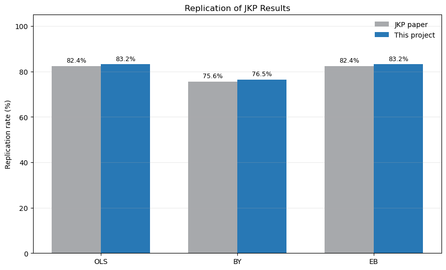

Figure 1: Replication rates: JKP paper versus this project

## Factor Themes

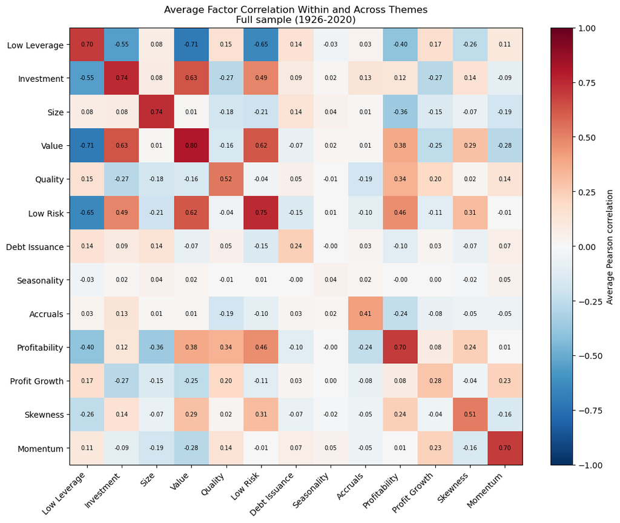

Figure 2: Average factor correlations within and across themes

The factors are grouped into 13 themes based on CAPM-residual correlations over 1975–2020. The heatmap shows strong within-theme correlations for several themes, while the EB replication rates reveal substantial variation across themes. Momentum, Accruals, Debt Issuance, Low Risk, and Quality achieve 100% replication, compared with 25% for Size and 0% for Low Leverage. Results for themes with few factors should be interpreted cautiously.

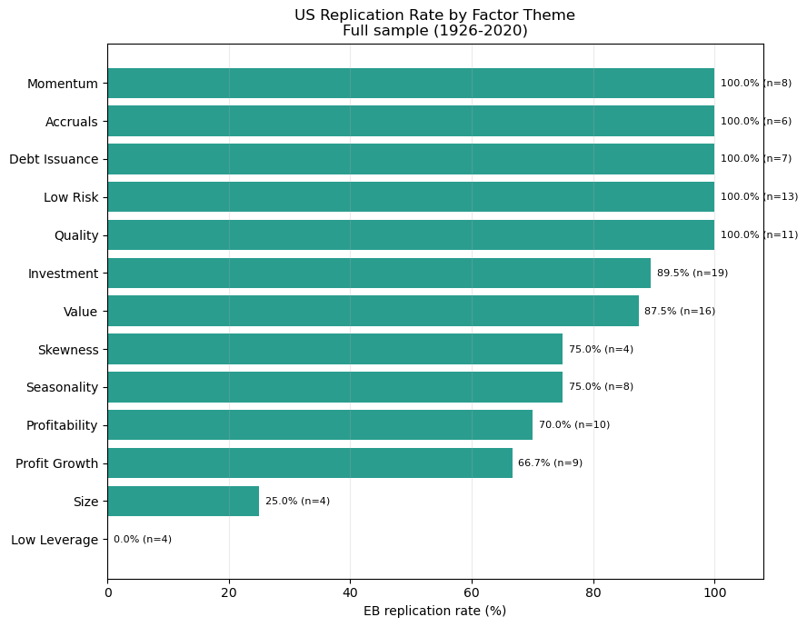

Figure 3: EB replication rates by factor theme

## Modern Sample Validation

Replication rates decline substantially in the 2000–2019 subsample. OLS falls from 83.2% to 58.8%, BY from 76.5% to 20.2%, and EB from 83.2% to 42.0%. This suggests weaker factor robustness in the modern period, although the shorter sample also reduces statistical power.

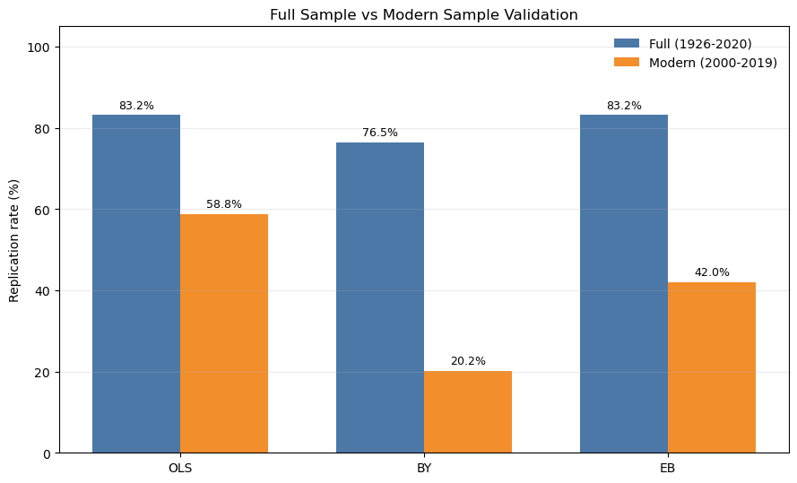

Figure 4: Full sample versus modern sample replication rates

# Alpha Models

This section develops two types of alpha signals. QMJ provides a transparent rule based benchmark, while machine learning models use firm characteristics to estimate the probability that a stock’s next month excess return will exceed the cross sectional median.

## QMJ Alpha Model

Following Asness, Frazzini, and Pedersen (2019), firm quality is defined using three dimensions: profitability, growth, and safety. QMJ provides a transparent rule-based benchmark in which firms with stronger fundamentals receive higher quality scores, which are used as alpha signals in this project.

Each month, characteristic $x_{i,t}$ is ranked across stocks and standardized:

$$z_t(x_{i,t})
=
\frac{
\operatorname{rank}_t(x_{i,t})-\mu_{r,t}
}{
\sigma_{r,t}
},$$

where $\mu_{r,t}$ and $\sigma_{r,t}$ are the cross-sectional mean and standard deviation of the ranks.

Profitability combines gross profits over assets (GPOA), return on equity (ROE), return on assets (ROA), cash flow over assets (CFOA), gross margin (GMAR), and low accruals (ACC):

$$\mathrm{PROF}_{i,t}
=
z_t\left[
\frac{1}{6}
\left(
z_{\mathrm{GPOA},i,t}
+
z_{\mathrm{ROE},i,t}
+
z_{\mathrm{ROA},i,t}
+
z_{\mathrm{CFOA},i,t}
+
z_{\mathrm{GMAR},i,t}
+
z_{\mathrm{ACC},i,t}
\right)
\right].$$

Growth measures the five-year growth in the corresponding residual per-share profitability measures, excluding accruals:

$$\mathrm{GROW}_{i,t}
=
z_t\left[
\frac{1}{5}
\left(
z_{\Delta_5\mathrm{GPOA},i,t}
+
z_{\Delta_5\mathrm{ROE},i,t}
+
z_{\Delta_5\mathrm{ROA},i,t}
+
z_{\Delta_5\mathrm{CFOA},i,t}
+
z_{\Delta_5\mathrm{GMAR},i,t}
\right)
\right].$$

Safety combines low market beta (BAB), low leverage (LEV), low bankruptcy risk based on the O-Score and Z-Score, and low ROE volatility (EVOL):

$$\mathrm{SAFE}_{i,t}
=
z_t\left[
\frac{1}{5}
\left(
z_{\mathrm{BAB},i,t}
+
z_{\mathrm{LEV},i,t}
+
z_{\mathrm{O},i,t}
+
z_{\mathrm{Z},i,t}
+
z_{\mathrm{EVOL},i,t}
\right)
\right].$$

All safety measures are signed so that higher values represent safer firms. The three components are equally weighted to produce the overall quality score:

$$Q_{i,t}
=
z_t\left[
\frac{
\mathrm{PROF}_{i,t}
+
\mathrm{GROW}_{i,t}
+
\mathrm{SAFE}_{i,t}
}{3}
\right].$$

When an individual measure is unavailable, the remaining available measures are averaged. A higher $Q_{i,t}$ indicates a more profitable, growing, and financially safe firm.

In the original paper, stocks are first divided into small and large cap groups and then sorted by quality. The resulting portfolios are value weighted and rebalanced monthly. The QMJ factor is long high quality stocks and short low quality, or junk, stocks within both size groups:

$$QMJ_t
=
\frac{1}{2}
\left(
R_{SQ,t}+R_{BQ,t}
\right)
-
\frac{1}{2}
\left(
R_{SJ,t}+R_{BJ,t}
\right),$$

where $S$ and $B$ denote small and big stocks, while $Q$ and $J$ denote quality and junk stocks.

For this project, the stock-level quality score is used directly as the rule-based alpha signal:

$$s^{\mathrm{QMJ}}_{i,t}
=
Q_{i,t}.$$

Stocks with higher QMJ scores are assigned higher expected-return rankings for subsequent portfolio construction.

## Machine Learning Alpha Models

### Prediction Target

The prediction target, $Y^{1M}_{i,t}$, indicates whether stock $i$’s next month excess return exceeds the cross sectional median return in month $t$:

$$Y^{1M}_{i,t}
=
\begin{cases}
1,
&
r_{i,t+1}
>
\operatorname{Median}_{j\in\mathcal{U}_t}
\left(r_{j,t+1}\right) \\[6pt]
0,
&
r_{i,t+1}
\leq
\operatorname{Median}_{j\in\mathcal{U}_t}
\left(r_{j,t+1}\right)
\end{cases}$$

where $r_{i,t+1}$ is stock $i$’s next-month excess return and $\mathcal{U}_t$ is the set of stocks with available returns in month $t$.

Using stock characteristics $X_{i,t}$, each model estimates

$$\widehat{p}_{i,t}
=
P\left(
Y^{1M}_{i,t}=1
\mid
X_{i,t}
\right).$$

The predicted probability $\widehat{p}_{i,t}$ is subsequently used as the stock level alpha score. Since the target is defined relative to the monthly median, the two classes are approximately balanced by construction.

### Feature Selection

To reduce redundancy among the 153 JKP characteristics, feature selection was performed using observations from 2000–2009. A random sample of 350,000 stock-month observations was used, and missing values were replaced with the corresponding training-sample medians.

The characteristics were grouped using complete-linkage hierarchical clustering. The distance between characteristics (j) and (k) was defined as

$$d_{jk}=1-\left|\rho_{jk}\right|,$$

The hierarchy was divided into 100 clusters, and the characteristic with the highest variance within each cluster was retained as its representative. This reduced the feature set from 153 to 100 characteristics.

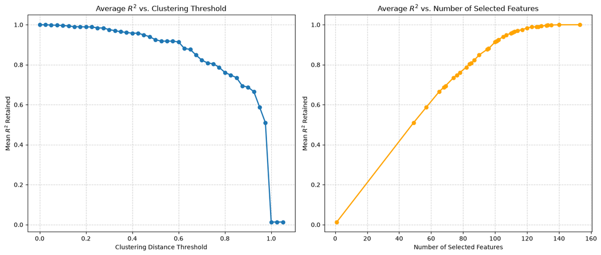

Figure 5: Information retained under hierarchical feature selection

As shown in Figure 5, retaining 100 features preserves an average $R^2$ of 0.9137, or approximately 91.4% of the information in the original feature set. Subsequent models are estimated using both the full 153-feature set and the selected 100-feature subset.

### Machine Learning Models

Three classification models are considered: `Logistic Regression`, `Random Forest`, and `XGBoost`. `Logistic Regression` provides a transparent linear benchmark, while `Random Forest` captures nonlinear relationships and interactions by combining multiple decision trees. `XGBoost` builds trees sequentially to improve prediction accuracy.

Each model is trained using both the full set of 153 characteristics and the selected subset of 100 characteristics. Hyperparameters are selected through time-series cross-validation. The predicted probability of outperforming the monthly median is subsequently used as the stock-level alpha score.

### Cross Validation and Hyperparameter Tuning

An expanding-window time-series cross-validation procedure was used to preserve the chronological order of the data and prevent future information from entering the training sample. The five folds were constructed as follows:

| Fold | Training Period | Validation Period |
| --- | --- | --- |
| 1 | Jan. 2000–Nov. 2009 | Jan.–Dec. 2010 |
| 2 | Jan. 2000–Nov. 2010 | Jan.–Dec. 2011 |
| 3 | Jan. 2000–Nov. 2011 | Jan.–Dec. 2012 |
| 4 | Jan. 2000–Nov. 2012 | Jan.–Dec. 2013 |
| 5 | Jan. 2000–Nov. 2013 | Jan.–Dec. 2014 |

A one-month gap was maintained between each training and validation window. Hyperparameter tuning was conducted separately for the full 153-feature set and the selected 100-feature subset. ROC-AUC was used as the primary model-selection criterion, while accuracy and log loss were also reported.

A two-stage tuning procedure was applied. The first stage searched over a broad parameter range, while the second stage conducted a narrower search around the best-performing region.

- `Logistic Regression`: The first stage tested both `L1` and `L2` penalties with `C` values from 0.001 to 10. The refined stage focused on the `L1` penalty and smaller `C` values between 0.0001 and 0.003.
- `Random Forest`: The first stage varied the `number of trees`, `maximum tree depth`, and `number of features` considered at each split. The refined stage focused on 300–500 trees, maximum depths of 15–20, and square-root feature sampling.
- `XGBoost`: The first stage searched across the `number of trees`, `maximum tree depth`, and `learning rate`. The refined ranges were selected separately for the full and selected feature sets based on the first-stage results.

The parameter combination with the highest average validation ROC-AUC across the five folds was selected for each model and feature set.

### Validation Results

| Model | Feature Set | Best Parameters | ROC-AUC | Accuracy | Log Loss |
| --- | --- | --- | --- | --- | --- |
| Logistic Regression | Full 153 | L1, $C=0.001$ | 0.5556 | 54.10% | 0.6888 |
| Logistic Regression | Selected 100 | L1, $C=0.001$ | 0.5538 | 53.93% | 0.6893 |
| Random Forest | Full 153 | 500 trees, depth 20, sqrt features | 0.5609 | 54.19% | 0.6876 |
| Random Forest | Selected 100 | 500 trees, depth 15, sqrt features | **0.5610** | 54.23% | 0.6877 |
| XGBoost | Full 153 | 500 trees, depth 5, learning rate 0.05 | 0.5595 | 54.28% | 0.6876 |
| XGBoost | Selected 100 | 500 trees, depth 7, learning rate 0.01 | 0.5605 | **54.32%** | **0.6874** |

All models achieve ROC-AUC values above the random benchmark of 0.5, although their predictive performance remains modest. Random Forest using the selected 100 features produces the highest ROC-AUC of 0.5610, while XGBoost using the selected features achieves the highest accuracy and lowest log loss.

The selected feature subset performs slightly better for both tree-based models, suggesting that clustering removes redundant information without reducing predictive power. In contrast, Logistic Regression performs slightly better using all 153 features. Because the objective is to rank stocks rather than make final binary trading decisions, ROC-AUC is used as the primary model-selection criterion. The economic value of these predictions is evaluated later through portfolio backtesting.

# Risk Model and Portfolio Optimization

## Factor Risk Model

Following the Bloomberg Global Equity Fundamental Factor Model, stock returns are decomposed into systematic factor returns and idiosyncratic returns. The covariance matrix of stock returns is estimated as

$$\Omega
=
X F X^{\top}
+
\Delta,$$

where:

- $\Omega$ is the $N \times N$ stock-return covariance matrix;
- $X$ is the $N \times K$ factor-exposure matrix;
- $F$ is the $K \times K$ factor-return covariance matrix;
- $\Delta$ is the idiosyncratic covariance matrix.

The idiosyncratic covariance matrix is assumed to be diagonal, with each diagonal element representing the idiosyncratic variance of one stock. Under this structure, portfolio variance can be decomposed into systematic and idiosyncratic risk:

$$\sigma_{p}^{2}
=
w^{\top}\Omega w
=
w^{\top}X F X^{\top}w
+
w^{\top}\Delta w.$$

## Factor Covariance Matrix

The factor covariance matrix is decomposed into factor volatilities and factor correlations:

$$F
=
V C V,$$

where $V$ is a diagonal matrix of factor volatilities and $C$ is the factor correlation matrix. Following Bloomberg, factor volatilities are estimated using an exponentially weighted moving average with a 26 week half-life.

The factor-correlation matrix combines an exponentially weighted historical correlation matrix with a PCA correlation matrix:

$$C
=
0.8C_{0}
+
0.2C_{P},$$

where $C_{0}$ is estimated using an exponentially weighted moving average with a 52-week half-life, while $C_{P}$ is constructed from the principal components associated with the largest eigenvalues. This combination retains economically meaningful historical relationships while reducing estimation noise.

## Portfolio Optimization

At the end of each month, the alpha signal and estimated covariance matrix are used to determine portfolio weights. The optimization problem is

$$\max_{w}
\left\{
\alpha^{\top}w
-
\frac{\lambda}{2}
w^{\top}\Omega w
\right\},$$

where $\alpha$ is the vector of QMJ or machine-learning alpha scores, $w$ is the vector of portfolio weights, and $\lambda$ is the risk-aversion parameter.

The first term rewards exposure to stocks with higher alpha scores, while the second term penalizes predicted portfolio risk. A larger value of $\lambda$ produces a more risk-controlled portfolio. The optimization is subject to the relevant budget, long-short exposure, and maximum-position constraints of each strategy.

# Backtest

## Probability Weighted Portfolio Construction

These baseline portfolios do not use a covariance matrix or a risk-model penalty. Therefore, the resulting performance primarily reflects the economic value of the machine-learning signals.

### Long-Only: Top 10%

For each month, the long-only portfolio selects the 10% of stocks with the highest predicted probabilities. Let $\mathcal{L}_{t}^{10}$ denote this selected set:

$$\mathcal{L}_{t}^{10}
=
\left\{
i:
\hat{p}_{i,t}
\geq
Q_{0.90,t}
\right\},$$

where $Q_{0.90,t}$ is the 90th percentile of predicted probabilities in month $t$.

Within the selected group, portfolio weights are proportional to the predicted probabilities:

$$w_{i,t} = \frac{\hat{p}_{i,t}}{\sum_{j\in\mathcal{L}_{t}^{10}}\hat{p}_{j,t}},$$

The portfolio is fully invested and long-only:

$$\sum_i w_{i,t}=1,
\qquad
w_{i,t}\geq 0.$$

The portfolio formed at month $t$ is evaluated using the realized excess returns in month $t+1$:

$$R_{t+1}
=
\sum_i
w_{i,t}
r_{i,t+1}.$$

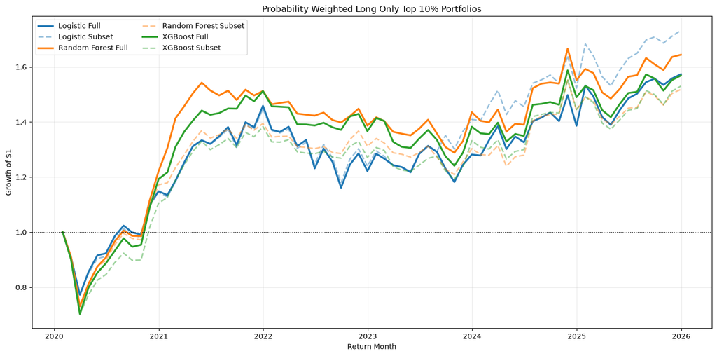

| Strategy | Annualized Return | Annualized Volatility | Annualized Sharpe | Cumulative Return | Max Drawdown |
| --- | --- | --- | --- | --- | --- |
| Logistic Subset | 10.68% | 16.53% | 0.646 | 73.26% | -22.62% |
| Random Forest Full | 9.82% | 16.63% | 0.591 | 64.41% | -26.95% |
| Logistic Full | 9.13% | 17.06% | 0.535 | 57.33% | -22.71% |
| XGBoost Full | 9.19% | 17.49% | 0.525 | 56.88% | -29.66% |
| XGBoost Subset | 8.68% | 16.90% | 0.514 | 53.03% | -29.78% |
| Random Forest Subset | 8.31% | 15.63% | 0.532 | 51.82% | -26.45% |

### Long-Short: Top and Bottom 5%

For each month, the long-short portfolio buys the 5% of stocks with the highest predicted probabilities and shorts the 5% with the lowest predicted probabilities. The two sets are defined as:

$$\mathcal{L}_{t}^{5}
=
\left\{
i:
\hat{p}_{i,t}\geq Q_{0.95,t}
\right\},
\qquad
\mathcal{S}_{t}^{5}
=
\left\{
i:
\hat{p}_{i,t}\leq Q_{0.05,t}
\right\}.$$

Within the long leg, weights are proportional to $\hat{p}_{i,t}$. Within the short leg, the short-confidence score is defined as $1-\hat{p}_{i,t}$, so stocks with lower predicted probabilities receive larger absolute short weights.

The final portfolio weights are:

$$w_{i,t}
=
\begin{cases}
\displaystyle
0.5
\frac{\hat{p}_{i,t}}
{\sum_{j\in\mathcal{L}_{t}^{5}}\hat{p}_{j,t}},
& i\in\mathcal{L}_{t}^{5}, \\[14pt]
\displaystyle
-0.5
\frac{1-\hat{p}_{i,t}}
{\sum_{j\in\mathcal{S}_{t}^{5}}
(1-\hat{p}_{j,t})},
& i\in\mathcal{S}_{t}^{5}, \\[14pt]
\end{cases}$$

The portfolio allocates 50% gross exposure to each side, producing a dollar-neutral portfolio with 100% total gross exposure:

$$\sum_i w_{i,t}=0,
\qquad
\sum_i
\left|
w_{i,t}
\right|
=1.$$

Its realized return is:

$$R_{t+1}
=
\sum_i
w_{i,t}
r_{i,t+1}
=
0.5
\left(
R_{t+1}^{\mathrm{Long}}
-
R_{t+1}^{\mathrm{Short}}
\right).$$

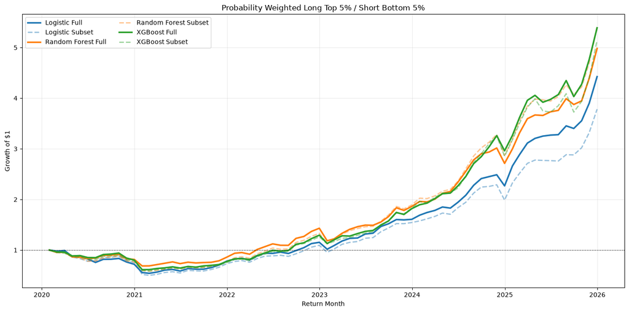

| Strategy | Annualized Return | Annualized Volatility | Annualized Sharpe | Cumulative Return | Max Drawdown |
| --- | --- | --- | --- | --- | --- |
| Random Forest Subset | 31.53% | 22.80% | 1.383 | 441.39% | -41.86% |
| XGBoost Full | 31.23% | 21.75% | 1.436 | 439.00% | -38.74% |
| XGBoost Subset | 30.72% | 23.12% | 1.329 | 414.18% | -41.64% |
| Random Forest Full | 29.62% | 20.79% | 1.425 | 398.28% | -31.42% |
| Logistic Full | 27.89% | 22.15% | 1.259 | 342.59% | -45.95% |
| Logistic Subset | 25.89% | 24.49% | 1.057 | 278.28% | -50.02% |

## Portfolio Construction with Risk Model

The probability weighted portfolios use only the machine learning predictions to determine portfolio weights. This section incorporates a factor risk model so that portfolio construction considers both predicted alpha and portfolio risk.

### Fundamental Factor Risk Model

The stock return covariance matrix is estimated as:

$$\boldsymbol{\Omega}
=
\mathbf{X}
\mathbf{F}
\mathbf{X}'
+
\boldsymbol{\Delta},$$

where $\mathbf{X}$ contains stock-level factor exposures, $\mathbf{F}$ is the factor covariance matrix, and $\boldsymbol{\Delta}$ contains stock-specific variances.

The factor covariance matrix is given by:

$$\mathbf{F}
=
\mathbf{V}
\mathbf{C}
\mathbf{V},$$

where $\mathbf{V}$ contains estimated factor volatilities. Following the Bloomberg-inspired risk-model structure (Cahan and Ji 2016), the factor correlation matrix combines EWMA and PCA estimates:

$$\mathbf{C}
=
0.8\mathbf{C}_{0}
+
0.2\mathbf{C}_{P}.$$

Here, $\mathbf{C}_{0}$ captures time-varying historical correlations, while $\mathbf{C}_{P}$ provides a more stable PCA-based estimate.

### Optimization and Backtest Setup

The predicted probabilities from each machine-learning model are treated as cross-sectional alpha scores. Portfolio weights are obtained by solving:

$$\mathbf{w}^*
=
\underset{\mathbf{w}}{\operatorname{arg\,max}}
\left[
\boldsymbol{\alpha}'\mathbf{w}
-
\frac{\lambda}{2}
\mathbf{w}'
\boldsymbol{\Omega}
\mathbf{w}
\right].$$

The first term rewards exposure to stronger alpha signals, while the second penalizes predicted portfolio variance. The optimization is evaluated using:

$$\lambda \in \{0,100,300,1000\}.$$

When $\lambda=0$, portfolio construction depends only on the alpha signal and portfolio constraints. Larger values of $\lambda$ place greater emphasis on risk control.

For the long-short strategy, the top and bottom 5% of stocks ranked by predicted probability form the long and short candidate sets. Each stock is subject to a maximum absolute weight of 1%.

At the end of month $t$, alpha forecasts, risk estimates, and portfolio weights are calculated using only information available at that time. Performance is then evaluated using realized returns in month $t+1$.

### Risk-Managed Backtest Results

The risk-model backtest is conducted using XGBoost Full and Random Forest Sub. QMJ is the primary long-short benchmark, while the S&P 500 is included as a market-performance reference. All return series cover the same evaluation period and are normalized to an initial value of one.

The accompanying tables report annualized mean return, annualized volatility, annualized Sharpe ratio, cumulative return, and maximum drawdown.

#### Random Forest Sub

Figure 8 presents the corresponding cumulative performance comparison for the Random Forest Sub model.

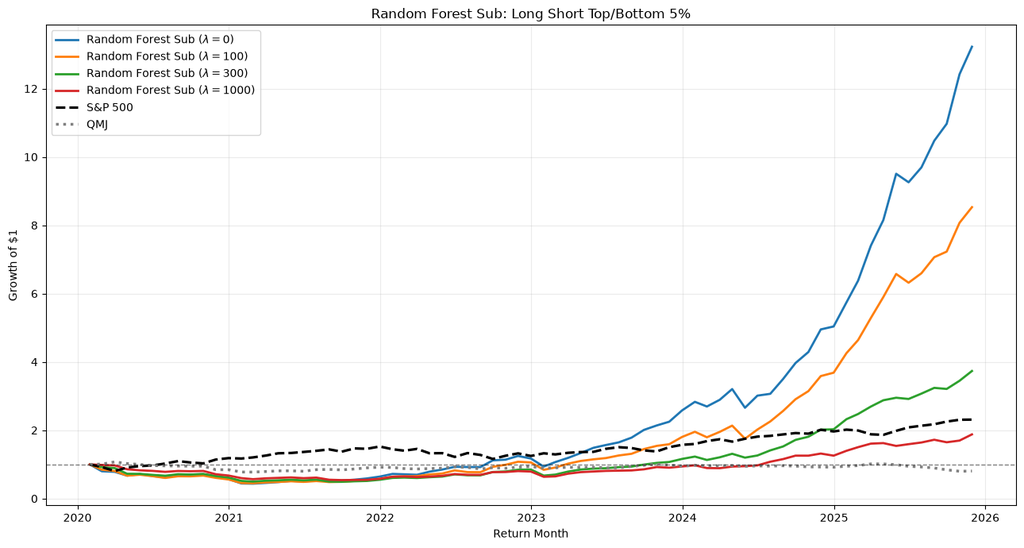

Figure 8: Cumulative performance of the risk-optimized Random Forest Sub Long-Short Top/Bottom 5% portfolios across different risk-aversion parameters.

Table 3 reports the performance metrics for the Random Forest Sub portfolios and benchmark series.

Table 3: Performance metrics for the risk-optimized Random Forest Sub portfolios and benchmark series.

|  | Annualized Return | Annualized Volatility | Annualized Sharpe | Cumulative Return | Max Drawdown |
| --- | --- | --- | --- | --- | --- |
| 0 | 53.20% | 33.07% | 1.609 | 1489.52% | -56.38% |
| 100 | 44.16% | 30.71% | 1.438 | 890.76% | -55.02% |
| 300 | 28.19% | 25.26% | 1.116 | 331.11% | -50.77% |
| 1000 | 14.56% | 20.97% | 0.694 | 106.84% | -45.97% |
| S&P 500 | 15.94% | 17.36% | 0.918 | 131.11% | -23.93% |
| QMJ | -3.09% | 11.02% | -0.280 | -19.43% | -27.77% |

#### XGBoost Full

Figure 9 compares the cumulative performance of the XGBoost Full portfolios across the four risk-aversion parameters.

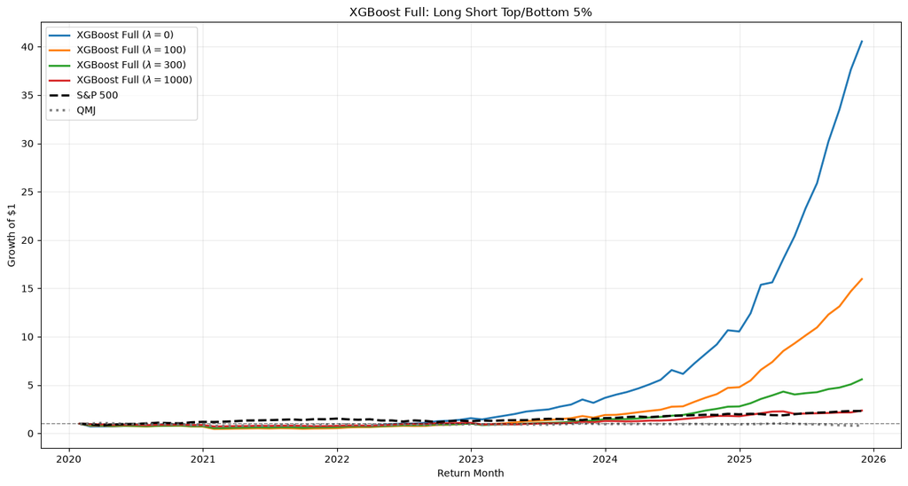

Figure 9: Cumulative performance of the risk-optimized XGBoost Full Long-Short Top/Bottom 5% portfolios across different risk-aversion parameters.

Table 4 reports the corresponding portfolio and benchmark performance metrics.

Table 4: Performance metrics for the risk-optimized XGBoost Full portfolios and benchmark series.

|  | Annualized Return | Annualized Volatility | Annualized Sharpe | Cumulative Return | Max Drawdown |
| --- | --- | --- | --- | --- | --- |
| 0 | 74.12% | 34.27% | 2.163 | 4892.41% | -49.86% |
| 100 | 54.16% | 30.72% | 1.763 | 1628.50% | -54.69% |
| 300 | 32.97% | 23.81% | 1.385 | 477.37% | -45.65% |
| 1000 | 15.91% | 18.39% | 0.865 | 130.54% | -28.88% |
| S&P 500 | 15.94% | 17.36% | 0.918 | 131.11% | -23.93% |
| QMJ | -3.09% | 11.02% | -0.280 | -19.43% | -27.77% |

# References

Asness, Clifford S., Andrea Frazzini, and Lasse Heje Pedersen. 2019. “Quality Minus Junk.” *Review of Accounting Studies* 24 (1): 34–112. https://doi.org/10.1007/s11142-018-9470-2.

Cahan, Ercument, and Lei Ji. 2016. “Global Equity Fundamental Factor Model.” Portfolio and Risk Analytics White Paper. Bloomberg L.P.

Jensen, Theis Ingerslev, Bryan T. Kelly, and Lasse Heje Pedersen. 2023. “Is There a Replication Crisis in Finance?” *The Journal of Finance* 78 (5): 2465–2518. https://doi.org/10.1111/jofi.13249.